# Data Story on Happy Moments

The science of happiness is of increasing interest to psychologists and society in general. The heart of this discipline is to find out what makes us happy. HappyDB is a corpus of 100,000 crowd-sourced happy moments via Amazon’s Mechanical Turk. You can read more about it on https://arxiv.org/abs/1801.07746. Here, I explore a processed data set of HappyDB and try to answer the question, “What makes people happy?”

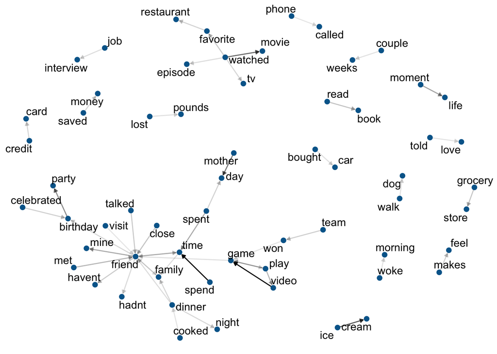

## What makes people happy?

### Comparison between reflection period of 24 hours and 3 months.

In this part, I would like to know the difference in the happy moment between these two groups. Therefore, I calculated how important a word is to each group using tf_idf in “tm” package. Below are top ten important words in reflection period of 24 hours and reflection period of 3 months.

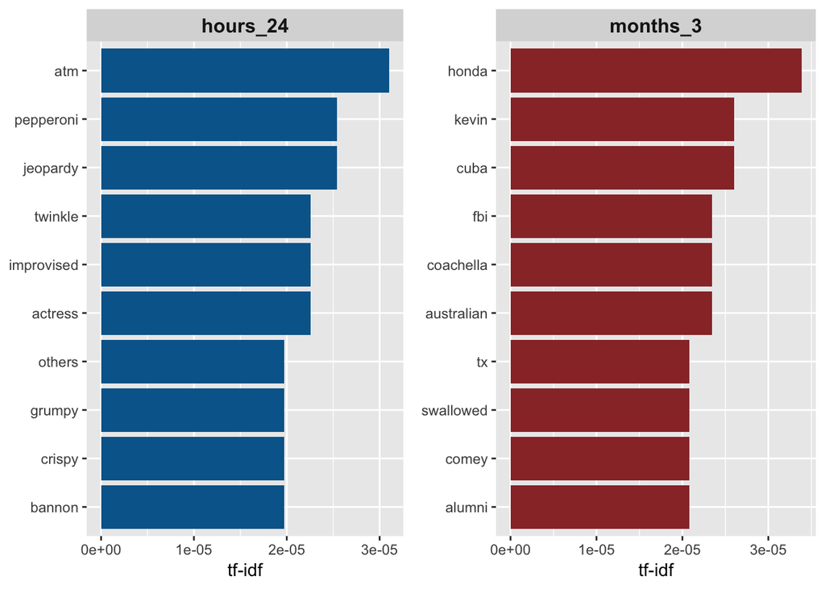

From these two bar charts, we could see that people more enjoy little things such as **food**, **TV show** and **trivial things** in the past 24 hours. For example, trying an improvised recipe from friends, having a crispy pepperoni pizza, or watching Jeopardy show. On the other hand, people more enjoy bigger things such as **travel**, **cars**, **music festivals**, and **political news**. For example, a trip to TX, buying a new Honda, going to Coachella, or story about FBI director James Comey getting fired. Basically, these results are consistent with what we experience in the daily life. **In the later part, I’ll focus on happy moments in the past three months to get a more general result.**

### Difference between male and female, married and single

Here I would like to see how gender and marital status affect one’s happy moment. Thus, I split the data into four groups: **Single Male**, **Single Female**, **Married Male**, and **Married Female**. After that, I calculated how important a word is to each group.

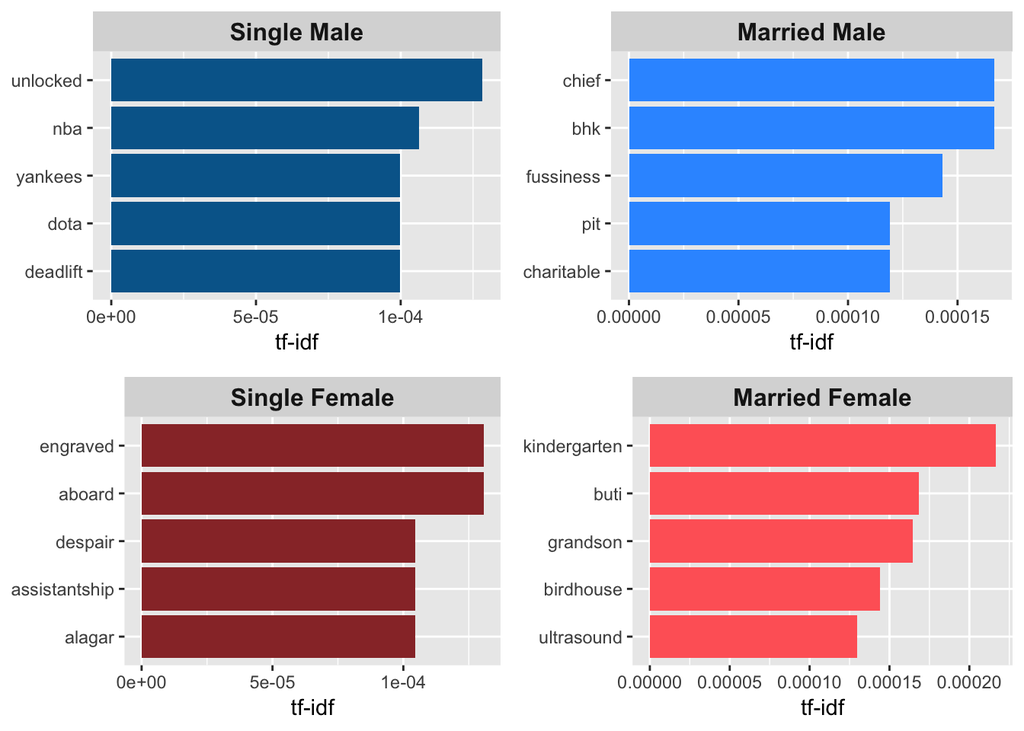

We could see that single men focus more on **fitness**, **sports**, and **video games**. NBA or Yankees game, dota game, unlocking game achievement and new lifting record can make single men happy. Married men concentrate on **promotion**, **family**, and **friend**. They are glad about getting promoted to a chief position, buying a BDH apartment, kids going to bed without fussiness, and a new fire pit in the backyard or a ball pit for kids. Single women care about **food**, **travel**, and **career achievement**. They are delighted by the new laser machine and getting the assistantship. Married women care about **children**, and **buti yoga**. Kids or about to have kids make them happy. The outcomes are consistent with our impression on these groups except the single female. The result of single female seems biased in the dataset.

### Does having a child affect people’s happy moments?

Below are top ten essential words to people who have children and who don’t have children. People said that having a kid would change your life. It’s true! We could see that people who have kids have happy moments more related to the family such as being called mommy or dada in the first time, seeing the improved behavior of their kids, or buying a new BHK apartment. On the other hand, people who don’t have children focus more on their personal experience.

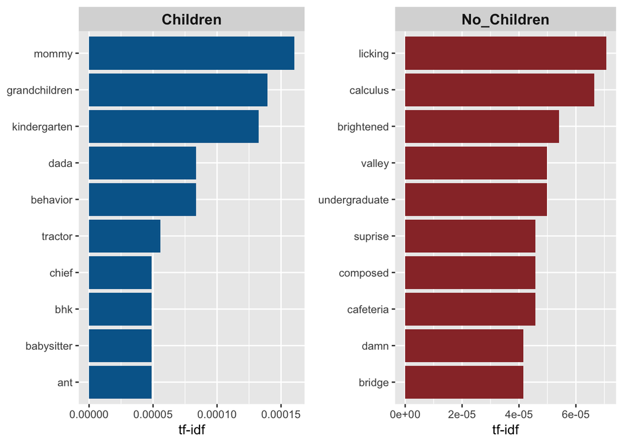

### Happy moments for people of different age

To see the happy moment for people of different age, I split the dataset to various age intervals. Since there are no data of people under 10 years old, the range starts from 10 to above 60. To receive a more distinctive result, I use word pairs to capture the difference in these smaller groups.

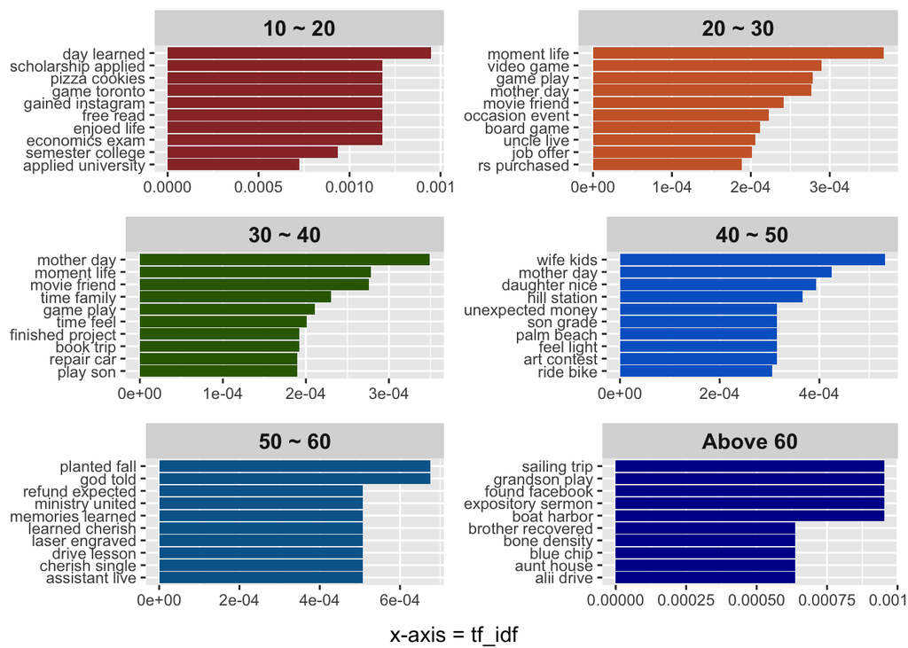

We could see that teenagers care more about **college life**, **recognition**, and **food**. People in their 20s like **video games** and getting a **job offer**. Moreover, People in their 30s focus more on **family** and **work**. People in their 40s are more sensitive to **children** and **vacation**. Furthermore, People in their 50s are happy to care for their **plants**. People of age over 60 are delighted with **sailing** and **expository sermons**. These results are consistent with people’s general preference.

### Summary

By analyzing the happiness dataset, we could get the following results.

- Children become the main focus once after people become parents.
- If you know sports and video games, you can get along with single men very well.
- Friends, family, life achievement are the most common source of happiness across all groups.